# Reference Analysis

Bohan Zhang, Audran Feuvrier

27 November 2026

```r
suppressPackageStartupMessages({
  library(sechm)
  library(edgeR)
  library(dplyr)
  library(stageR)
  library(ggplot2)
  library(patchwork)
  library(cowplot)
  library(ggrepel)
  library(ggplotify)
})
wd <- "/mnt/gapp/work/bohan/transcriptional_sex_difference_analysis_pitfalls/bohan_ver"
setwd(wd)
knitr::opts_knit$set(root.dir = wd)
knitr::opts_chunk$set(warning = FALSE, class.message = "msg")
source("./code/function.R")
```

# 1 Differential analysis: Contrast-based approach

## 1.1 Load data

We use the full dataset for this analysis

```r
se <- readRDS("./datasets/whole_vHC_dataset.rds")
dge <- DGEList(assay(se, "counts"))
mm <- model.matrix(~ 0 + group, data=as.data.frame(colData(se)))
dge <- calcNormFactors(dge)
# Filter lowly expressed genes
keep <- filterByExpr(dge, mm, min.count = 10)
se <- se[keep, ]

# First we use SVA correction to capture latent technical variation
# There are two embedded methods to estimate the number of SVs: BE and LEEK
# We take a look at both of their estimation
set.seed(1)
tmp <- SEtools::svacor(se, ~ 0 + group, numSVmethod = "be", method = "vst")
```

```
## Using variance-stabilizing transformation
```

```
## Number of significant surrogate variables is:  6
## Iteration (out of 5 ):1  2  3  4  5
```

```r
tmp <- SEtools::svacor(se, ~ 0 + group, numSVmethod = "leek", method = "vst")
```

```
## Using variance-stabilizing transformation
```

```
## No significant surrogate variables
```

```
## Nothing to do!
```

```r
# we use 6 SVs as "BE" suggested
se <- SEtools::svacor(se, ~ 0 + group, n.sv = 6, method = "vst")
```

```
## Using variance-stabilizing transformation
```

```
## Number of significant surrogate variables is:  6
## Iteration (out of 5 ):1  2  3  4  5
```

```r
se <- log2FC(se, "corrected", controls = grep("Ctrl", se$group), isLog = TRUE)  # calculate logFC relative to the mean of control samples
```

## 1.2 DEA

```r
dge <- calcNormFactors(DGEList(assay(se)))
formula <- as.formula(paste(c("~ 0 + group", grep("^SV[0-9]+$",colnames(colData(se)),value = TRUE)), collapse = "+"))
mm <- model.matrix(formula , data = as.data.frame(colData(se))) # include SVs in the model matrix
dge <- estimateDisp(dge, mm)
fit <- glmQLFit(dge, mm, pseudocount = 0.5)

# Define the constrasts to test for
# Here in the contrast-based approach, we can define contrasts explicityly rather than relying on model coefficients
# This avoids the reference sex bias described in the pitfalls section
contrast <- makeContrasts(
  Stress_vs_CTRL = (groupFemale_Stress + groupMale_Stress) / 2 - (groupFemale_Ctrl + groupMale_Ctrl) / 2,  # Overall stress effect, averaged equally across both sexes
  F_M_Stress = (groupFemale_Stress - groupFemale_Ctrl) - (groupMale_Stress - groupMale_Ctrl),  # Sex*Stress interaction: does the stress response differ between sexes?
  F_vs_M_Ctrl = groupFemale_Ctrl - groupMale_Ctrl,  # Baseline sex difference (in Ctrls only)
  F_vs_M_Stress = groupFemale_Stress - groupMale_Stress,  # Sex difference in Stress group
  F_Stress = groupFemale_Stress - groupFemale_Ctrl, # Stress response in females
  M_Stress = groupMale_Stress - groupMale_Ctrl, # Stress response in males
  levels = mm)

Results_stress <- addlogFCSE(as.data.frame(topTags(glmQLFTest(fit, contrast = contrast[, "Stress_vs_CTRL"]),Inf)))
# Difference stress vs no stress

Results_M <- addlogFCSE(as.data.frame(topTags(glmQLFTest(fit, contrast = contrast[, "M_Stress"]),Inf)))
# Difference stress vs no stress in males

Results_F <- addlogFCSE(as.data.frame(topTags(glmQLFTest(fit, contrast = contrast[, "F_Stress"]),Inf)))
# Difference stress vs no stress in females

Results_sex <- as.data.frame(topTags(glmQLFTest(fit, contrast = contrast[, "F_vs_M_Ctrl"]),Inf))
# Difference male vs female in Ctrl samples

Results_interaction <- addlogFCSE(as.data.frame(topTags(glmQLFTest(fit, contrast = contrast[,"F_M_Stress"]),Inf)))
# Difference in response to stress between sexes

Results <- as.data.frame(topTags(glmQLFTest(fit, contrast = contrast),Inf))
# All results

# save all the DEA results in SE object
rowData(se)$DEA.Stress_vs_CTRL <- addlogFCSE(as.data.frame(topTags(glmQLFTest(fit, contrast = contrast[, "Stress_vs_CTRL"]),Inf)))
rowData(se)$DEA.M_Stress <- addlogFCSE(as.data.frame(topTags(glmQLFTest(fit, contrast = contrast[, "M_Stress"]),Inf)))
rowData(se)$DEA.F_Stress <- addlogFCSE(as.data.frame(topTags(glmQLFTest(fit, contrast = contrast[, "F_Stress"]),Inf)))
rowData(se)$DEA.F_vs_M_Ctrl <- addlogFCSE(as.data.frame(topTags(glmQLFTest(fit, contrast = contrast[, "F_vs_M_Ctrl"]),Inf)))
rowData(se)$DEA.F_vs_M_Stress <- addlogFCSE(as.data.frame(topTags(glmQLFTest(fit, contrast = contrast[, "F_vs_M_Stress"]),Inf)))
rowData(se)$DEA.interaction <- addlogFCSE(as.data.frame(topTags(glmQLFTest(fit, contrast = contrast[,"F_M_Stress"]),Inf)))
rowData(se)$DEA.overall_result <- as.data.frame(topTags(glmQLFTest(fit, contrast = contrast),Inf))

# use stageR (two-stage FDR correction) to correct the Pvalue for interaction
# Here we first try to use the pvalue from All Results as the input of screening
pScreen <- Results$PValue
names(pScreen) <- rownames(Results)
pConfirmation <- cbind(Interaction = Results_interaction[row.names(Results),"PValue"])
stageRObj <- stageR(pScreen = pScreen, pConfirmation = pConfirmation, pScreenAdjusted = FALSE)
stageRObj <- stageWiseAdjustment(object = stageRObj, method = "none", alpha = 0.05)
adj_PVals <- getAdjustedPValues(stageRObj, onlySignificantGenes = FALSE, order = FALSE) #returns NA for non-significant gene in pScreen
```

```
## The returned adjusted p-values are based on a stage-wise testing approach and are only valid for the provided target OFDR level of 5%. If a different target OFDR level is of interest,the entire adjustment should be re-run.
```

```r
adj_PVals <- as.data.frame(adj_PVals)
Results_interaction$staged.FDR <- adj_PVals[rownames(Results_interaction),]$"Interaction"

M_signif <- rownames(Results_M[Results_M$FDR < 0.05, ])
F_signif <- rownames(Results_F[Results_F$FDR < 0.05, ])
intDEGs <- rownames(na.omit(Results_interaction[Results_interaction$staged.FDR < 0.05, ]))
intDEGs
```

```
##  [1] "ENSMUSG00000111133.Gm5831"        "ENSMUSG00000057137.Tmem140"
##  [3] "ENSMUSG00000047409.Ctdspl"        "ENSMUSG00000103567.Pcdhga5"
##  [5] "ENSMUSG00000075478.Slitrk1"       "ENSMUSG00000094437.Gm9830"
##  [7] "ENSMUSG00000079224.Gm6565"        "ENSMUSG00000064220.H2ac18"
##  [9] "ENSMUSG00000048572.Tmem252"       "ENSMUSG00000039257.Vstm2b"
## [11] "ENSMUSG00000082163.Gm14276"       "ENSMUSG00000021032.Ngb"
## [13] "ENSMUSG00000050147.F2rl3"         "ENSMUSG00000005370.Msh6"
## [15] "ENSMUSG00000015947.Fcgr1"         "ENSMUSG00000041078.Grid1"
## [17] "ENSMUSG00000038451.Spsb2"         "ENSMUSG00000101111.Gm28437"
## [19] "ENSMUSG00000029034.Ints11"        "ENSMUSG00000032062.2310030G06Rik"
## [21] "ENSMUSG00000039556.Ppp1r3f"       "ENSMUSG00000048001.Hes5"
## [23] "ENSMUSG00000048546.Tob2"          "ENSMUSG00000038742.Angptl6"
## [25] "ENSMUSG00000018425.Dhx40"         "ENSMUSG00000037997.Parp11"
## [27] "ENSMUSG00000025815.Dhtkd1"        "ENSMUSG00000037110.Ralgapa2"
## [29] "ENSMUSG00000114905.Gm48113"       "ENSMUSG00000024414.Mrpl27"
```

[output cut: 35 more lines]

### 1.2.1 Fig 6A

Volcano plot of the differential analysis result (Sex*Stress interaction)

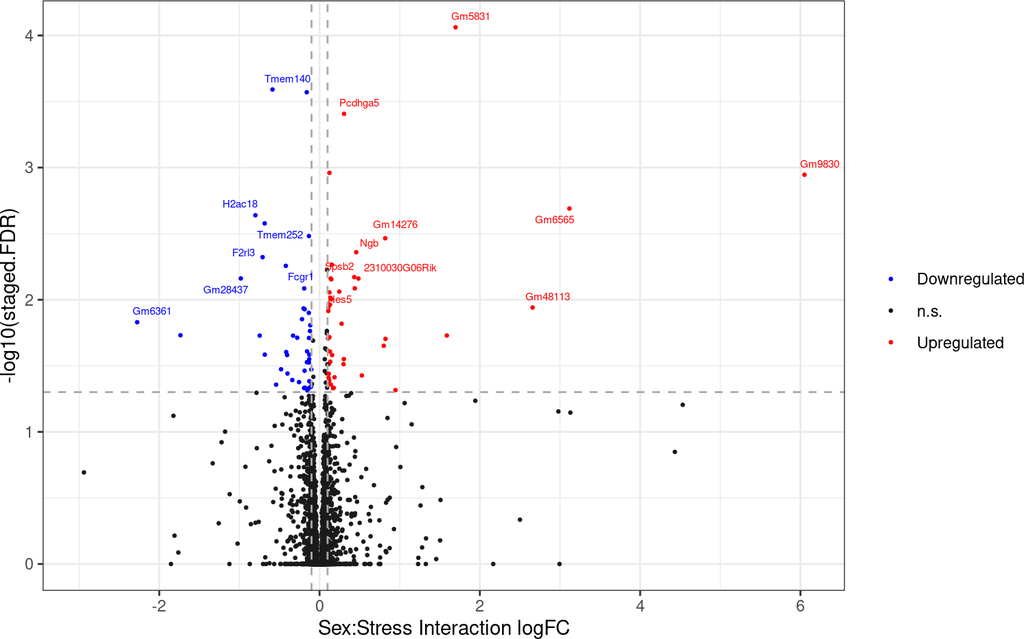

```r
show <- row.names(Results_interaction)[which(Results_interaction$staged.FDR < 0.015 & abs(Results_interaction$logFC) > 0.25)]
fig6a <- volcano(Results_interaction, logFC = logFC, signif = staged.FDR, labels = show) +
  coord_cartesian(xlim = c(-3, 6.1)) +
  labs(x = "Sex:Stress Interaction logFC")
fig6a
```

### 1.2.2 Fig 6B

Heatmap of significant interaction genes after stageR correction

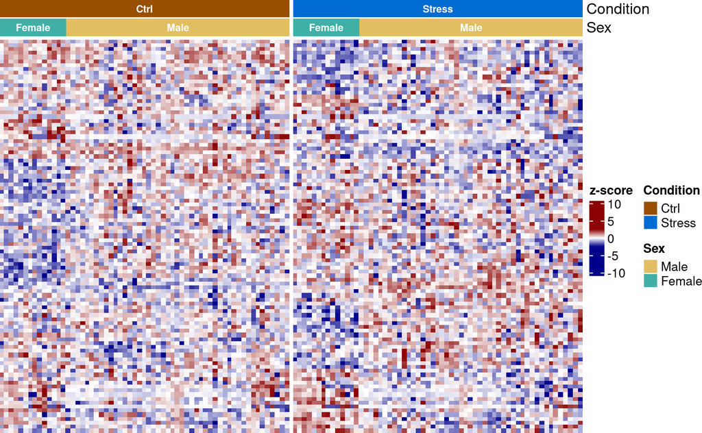

```r
fig6b <- sechm(
  se = se,
  feature = intDEGs,
  gaps_at = "Condition",
  assayName = "corrected",
  do.scale = TRUE,
  name = "z-score",
  top_annotation = c("Condition", "Sex"),
  anno_labels = TRUE,
  anno_label_gp = c(size = 8, col = "white"),  show_rownames = FALSE,
  cluster_rows = TRUE,
  show_row_dend = FALSE,
  breaks = 0.98,
  column_title = NULL,
  use_raster = TRUE
)
fig6b
```

### 1.2.3 Fig 6C

Correlation between interaction logFC and baseline logFC between sexes

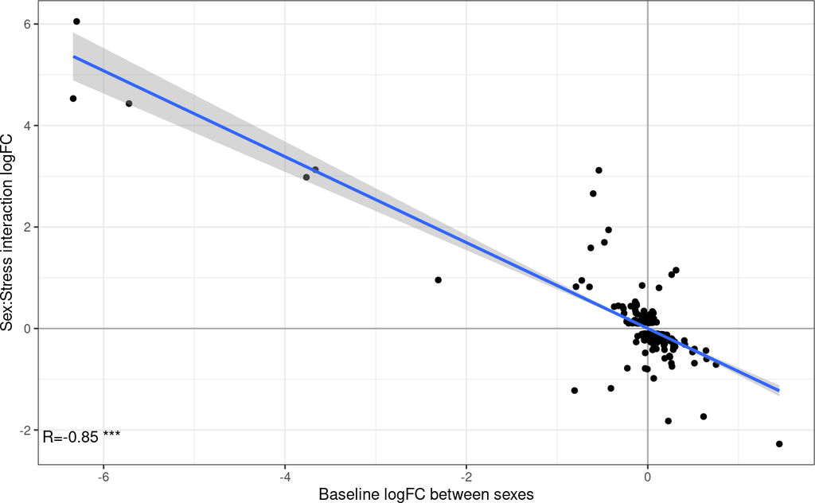

```r
Results_interaction$logFC.Sex <- Results_sex[row.names(Results_interaction), "logFC"]
Results_interaction$logFC.stressMales <- Results_M[row.names(Results_interaction), "logFC"]

Results_interaction2 <- Results_interaction[which(Results_interaction$staged.FDR < 0.15 & abs(Results_interaction$logFC) > 0.1),]
ct <- cor.test(Results_interaction2$logFC, Results_interaction2$logFC.Sex)
fig6c <- ggplot(Results_interaction2, aes(logFC.Sex, logFC)) +
  geom_vline(xintercept = 0, colour = "darkgray") +
  geom_hline(yintercept = 0, colour = "darkgray") +
  geom_point() +
  geom_smooth(formula = y ~ 0 + x, method = "lm") +
  theme_bw() +
  labs(x = "Baseline logFC between sexes", y = "Sex:Stress interaction logFC") +
  annotate("text", x = -Inf, y = -Inf, label = paste0(" R=", round(ct$estimate,2)," ***\n"), hjust = 0, vjust = 0)
fig6c
```

## 1.3 Improved stageR Strategy

```r
Results2 <- as.data.frame(topTags(glmQLFTest(fit, contrast = contrast[, c("F_Stress", "M_Stress", "F_M_Stress", "Stress_vs_CTRL")]),Inf))
pScreen2 <- Results2$PValue
names(pScreen2) <- rownames(Results2)

pConfirmation2 <- cbind(Interaction = Results_interaction[row.names(Results2),"PValue"])

stageRObj2 <- stageR(pScreen = pScreen2, pConfirmation = pConfirmation2, pScreenAdjusted = FALSE)
stageRObj2 <- stageWiseAdjustment(object = stageRObj2, method = "none", alpha = 0.05)

adj_PVals2 <- getAdjustedPValues(stageRObj2, onlySignificantGenes = FALSE, order = FALSE) #returns NA for non-significant gene in pScreen
```

```
## The returned adjusted p-values are based on a stage-wise testing approach and are only valid for the provided target OFDR level of 5%. If a different target OFDR level is of interest,the entire adjustment should be re-run.
```

```r
adj_PVals2 <- as.data.frame(adj_PVals2)

Results_interaction$staged.FDR <- adj_PVals2[rownames(Results_interaction),]$"Interaction"
intDEGs2 <- rownames(na.omit(Results_interaction[Results_interaction$staged.FDR < 0.05, ]))
intDEGs2
```

```
##  [1] "ENSMUSG00000111133.Gm5831"        "ENSMUSG00000057137.Tmem140"
##  [3] "ENSMUSG00000047409.Ctdspl"        "ENSMUSG00000103567.Pcdhga5"
##  [5] "ENSMUSG00000075478.Slitrk1"       "ENSMUSG00000094437.Gm9830"
##  [7] "ENSMUSG00000079224.Gm6565"        "ENSMUSG00000064220.H2ac18"
##  [9] "ENSMUSG00000048572.Tmem252"       "ENSMUSG00000039257.Vstm2b"
## [11] "ENSMUSG00000082163.Gm14276"       "ENSMUSG00000021032.Ngb"
## [13] "ENSMUSG00000050147.F2rl3"         "ENSMUSG00000005370.Msh6"
## [15] "ENSMUSG00000015947.Fcgr1"         "ENSMUSG00000041078.Grid1"
## [17] "ENSMUSG00000101111.Gm28437"       "ENSMUSG00000029034.Ints11"
## [19] "ENSMUSG00000032062.2310030G06Rik" "ENSMUSG00000048001.Hes5"
## [21] "ENSMUSG00000048546.Tob2"          "ENSMUSG00000038742.Angptl6"
## [23] "ENSMUSG00000018425.Dhx40"         "ENSMUSG00000025815.Dhtkd1"
## [25] "ENSMUSG00000037110.Ralgapa2"      "ENSMUSG00000024414.Mrpl27"
## [27] "ENSMUSG00000052748.Swt1"          "ENSMUSG00000020696.Rffl"
## [29] "ENSMUSG00000021236.Entpd5"        "ENSMUSG00000005699.Pard6a"
## [31] "ENSMUSG00000060862.Zbtb40"        "ENSMUSG00000068964.Gm6361"
```

```r
write.table(intDEGs2, "./objects/interaction_genes_swim_full_dataset.txt")  # for later use
write.table(Results_interaction, "./objects/DEA_interaction_result_swim_full_dataset.txt")  # for later use
rowData(se)$DEA.subset_overall_result <- as.data.frame(topTags(glmQLFTest(fit, contrast = contrast[, c("F_Stress", "M_Stress", "F_M_Stress", "Stress_vs_CTRL")]),Inf))
# save the staged.FDR in SE for interaction for later use
rowData(se)$Interaction_staged.FDR <- adj_PVals2[rownames(se),]$"Interaction"
```

### 1.3.1 Fig 6D

Compare logFC upon stress in males and in females of the genes with significant Sex*Stress interaction

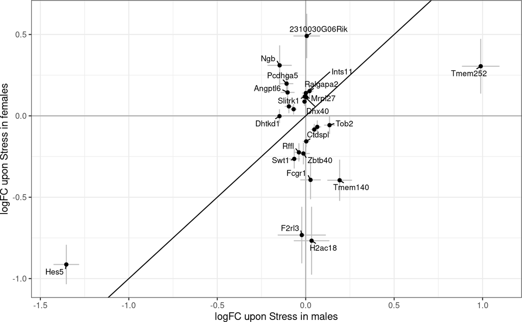

```r
merge_M_F <- merge(Results_M, Results_F, by = "row.names", suffix = c(".males", ".females"))

merge_M_F$proteinCoding <- rowData(se)[merge_M_F$Row.names, "proteinCoding"]

merge_M_F <- merge_M_F[which(merge_M_F$Row.names %in% intDEGs2 & merge_M_F$proteinCoding),] # select protein-coding genes with significant Sex*Stress interaction

fig6d <- ggplot(merge_M_F, aes(logFC.males, logFC.females)) +
  geom_vline(xintercept = 0, colour = "darkgray") +
  geom_hline(yintercept = 0, colour = "darkgray") +
  geom_abline(slope=1) +
  geom_segment(aes(y=low.females, yend=high.females), color="grey") +
  geom_segment(aes(x=low.males, xend=high.males), color="grey") +
  theme_bw() +
  geom_point() +
  ggrepel::geom_text_repel(data=merge_M_F[which(abs(merge_M_F$logFC.males)>0.1 | abs(merge_M_F$logFC.females)>0.1),],
    aes(label=gsub(".+\\.","",Row.names)), max.overlaps = 30, min.segment.length = 0, size=3) +
  labs(x="logFC upon Stress in males", y="logFC upon Stress in females")
fig6d
```

### 1.3.2 Fig 6E

Heatmap of protein-coding genes with significant Sex*Stress interaction

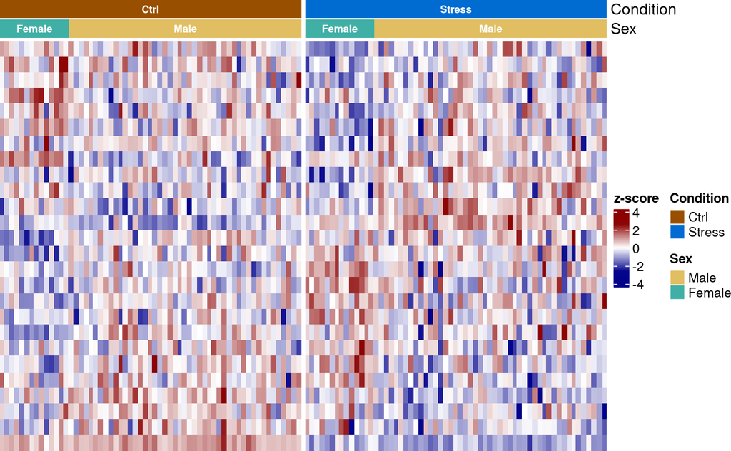

```r
cands2 <- intersect(intDEGs2, row.names(se)[which(rowData(se)$proteinCoding)])

fig6e <- sechm(
  se = se,
  feature = cands2,
  gaps_at = "Condition",
  assayName = "corrected",
  do.scale = TRUE,
  row_names_gp = gpar(fontsize=7),
  name = "z-score",
  top_annotation = c("Condition", "Sex"),
  anno_labels = TRUE,
  anno_label_gp = c(size = 8, col = "white"),  show_rownames = FALSE,
  breaks = 0.99,
  row_labels = gsub(".+\\.","",cands2),
  use_raster = TRUE,
  column_title = NULL
)
fig6e
```

### 1.3.3 Fig 6F

Show top ten genes with a significant interaction and the largest interaction logFC

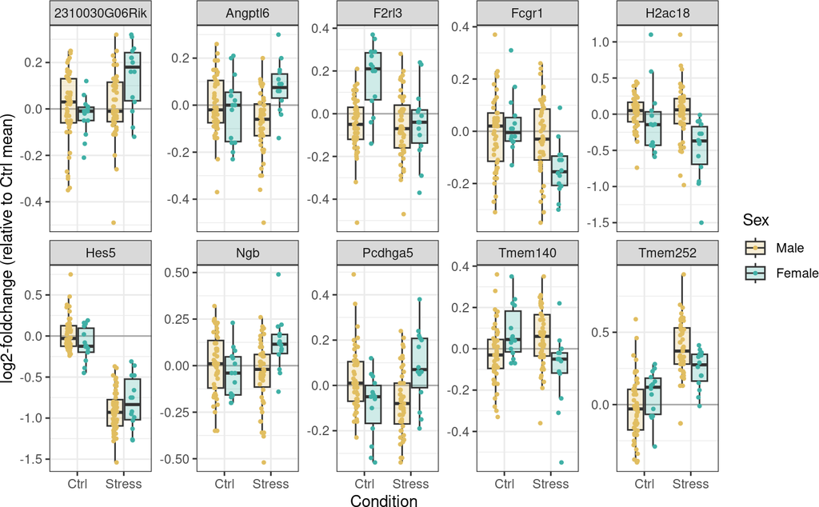

```r
intDF <- Results_interaction[order(abs(Results_interaction$logFC), decreasing = TRUE), ]
top10cand <- head(intDF[which(intDF$staged.FDR < 0.05 & abs(intDF$logFC) > 0.1 & rownames(intDF) %in% cands2),], 10)   # top10 candidates (protein-coding)
d <- meltSE(se, rownames(top10cand))
d$gene <- gsub(".+\\.","",d$feature)
fig6f <- ggplot(d, aes(Condition, log2FC)) +
  geom_hline(yintercept = 0, colour = "darkgray") +
  geom_boxplot(aes(fill=Sex), alpha=0.25, outliers=FALSE) +
  geom_point(aes(color=Sex), size=0.8, position=position_jitterdodge(jitter.width = 0.2, dodge.width = 0.75)) +
  facet_wrap(~gene, scale="free_y", nrow=2) +
  theme_bw() + scale_fill_manual(values=metadata(se)$anno_colors$Sex) +
  labs(y="log2-foldchange (relative to Ctrl mean)") +
  scale_color_manual(values=metadata(se)$anno_colors$Sex)
fig6f
```

### 1.3.4 Fig 6G

In (Brivio et al. 2020), several genes were reported to have a Sex*Stress interaction. Here we plot them with our data.

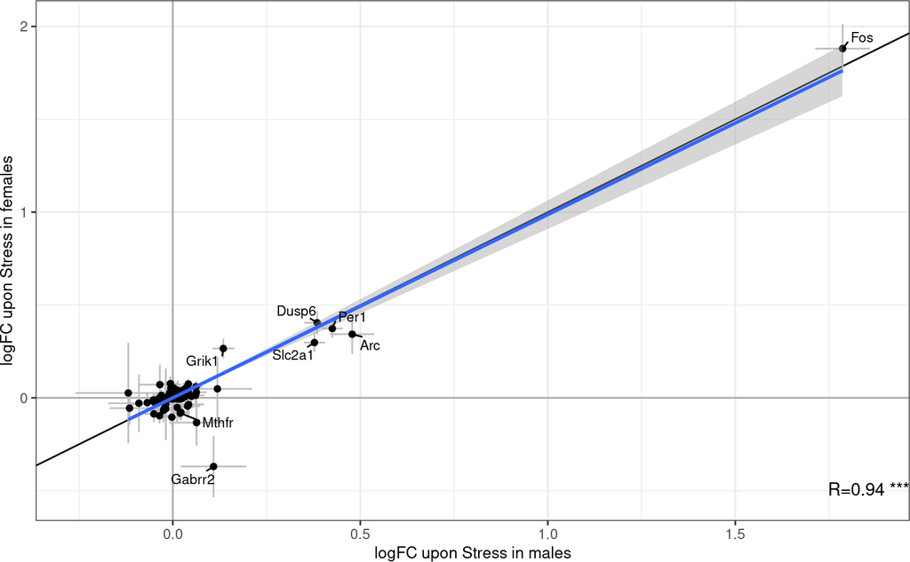

```r
brivioGenes <- tools::toTitleCase(tolower(readLines("./datasets/BrivioSexStressGenes2.txt")))
brivioGenes <- getrn(se, brivioGenes)
# check if they overlap with intDEGs:
overlap_gene <- intersect(brivioGenes, intDEGs)
# only Mthfr overlaps

# Visualization of BrivioGenes in our data:
merge_M_F <- merge(Results_M, Results_F, by="row.names", suffix=c(".males",".females"))
merge_M_F_brivio <- merge_M_F[which(merge_M_F$Row.names %in% brivioGenes),]
ct <- cor.test(merge_M_F_brivio$logFC.males, merge_M_F_brivio$logFC.females)
fig6g <- ggplot(merge_M_F_brivio, aes(logFC.males, logFC.females)) +
  geom_vline(xintercept = 0, colour = "darkgray") +
  geom_hline(yintercept = 0, colour = "darkgray") +
  geom_abline(slope = 1) +
  geom_segment(aes(y = low.females, yend = high.females), color = "grey") +
  geom_segment(aes(x = low.males, xend = high.males), color = "grey") +
  theme_bw() +
  theme(axis.title = element_text(size = 10)) +
  geom_point() +
  geom_smooth(formula = y ~ 0 + x, method = "lm") +
  ggrepel::geom_text_repel(data = merge_M_F_brivio[which(abs(merge_M_F_brivio$logFC.males) > 0.25 | abs(merge_M_F_brivio$logFC.females) > 0.25), ],
    aes(label = gsub(".+\\.","",Row.names)), max.overlaps = 30, min.segment.length = 0, size = 3) +
  ggrepel::geom_text_repel(data = merge_M_F_brivio[which(merge_M_F_brivio$Row.names %in% overlap_gene), ],
    aes(label = gsub(".+\\.","",Row.names)), nudge_x = 0.1, nudge_y = -0.05, max.overlaps = 30, min.segment.length = 0, size = 3) +
  labs(x = "logFC upon Stress in males", y = "logFC upon Stress in females") +
  annotate("text", x = Inf, y = -Inf, label = paste0(" R=", round(ct$estimate, 2), " ***\n"), hjust = 1, vjust = 0)
fig6g
```

Most of them do not show an interaction in our meta-analysis.

Note that these genes are not necessarily reported to have Sex*Stress interaction in the hippocampus and response to this specific stressor that we used.

### 1.3.5 Fig 6H

Firstly, we plot the overlap gene Mthfr.

Secondly, although not significant in our analysis, Gabrr2 was the only gene which showed a pattern consistent with a sex-specific regulation upon stress. Here we visualize its expression

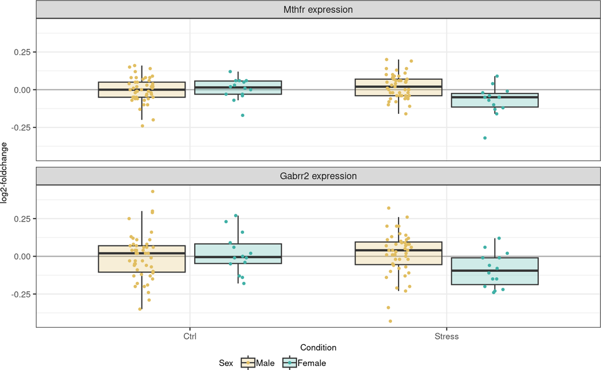

```r
gene_of_interest <- meltSE(se, getrn(se, c("Mthfr", "Gabrr2")))
gene_of_interest$feature <- gsub(".+\\.", "", gene_of_interest$feature)
fig6h <- ggplot(gene_of_interest, aes(Condition, log2FC)) +
    facet_wrap(~factor(feature, levels = c("Mthfr", "Gabrr2"), labels = c("Mthfr expression", "Gabrr2 expression")), nrow = 2) +
    geom_hline(yintercept = 0, colour = "darkgray") +
    geom_boxplot(aes(fill = Sex), alpha = 0.25, outliers = FALSE) +
    geom_point(aes(color = Sex), size = 0.8, position = position_jitterdodge(jitter.width = 0.2, dodge.width = 0.75)) +
    theme_bw() +
    scale_fill_manual(values = metadata(se)$anno_colors$Sex, name = "Sex") +
    scale_color_manual(values = metadata(se)$anno_colors$Sex, name = "Sex") +
    labs(y = "log2-foldchange") +
    theme(
      axis.title = element_text(size = 8),
      axis.text = element_text(size = 8),
      legend.position = "bottom",
      legend.justification = c(0.4, 0),
      legend.key.size = unit(0.6, "cm"),
      legend.text = element_text(size = 8, margin = margin(l = -1)),
      legend.title = element_text(size = 8),
      legend.margin = margin(t = -10))
fig6h
```

### 1.3.6 Fig 6I

In next chunk we ask: does female stress response differ systematically from male response? To answer this, we fit a regression of (female logFC - male logFC) ~ male logFC. We did this in three different gene sets: DEGs from full dataset; balanced DEGs; DEGs from balanced data.

```r
# Gene set 1. DEGs from differential analysis of the full dataset, both sexes pooled
merge_M_F <- merge(Results_M, Results_F, by = "row.names", suffix = c(".males",".females"))
m1 <- merge_M_F[which(merge_M_F$Row.names %in% row.names(Results_stress)[which(Results_stress$FDR < 0.05)]),]
# Here this gene set is selected form the analysis which is dominated by males (more samples in the data).
# So we might have detected more DEGs in males (since we have more power there), which could have led to a bias towards males
# # Thus we also use two other different gene sets.

# Gene set 2. balanced DEGs.
# Take the same number of top male DEGs as female DEGs, to avoid male-dominated gene selection
balanced_degs <- union(head(row.names(Results_M), sum(Results_F$FDR < 0.05)), row.names(Results_F)[which(Results_F$FDR < 0.05)])  # Since female has less significant genes than male, we extract the number of female DEGs
m2 <- merge_M_F[which(merge_M_F$Row.names %in% balanced_degs),]

# Gene set 3. DEGs from a sex-balanced dataset
# Here we select equal number of males and females, then re-run the differential analysis
# This also removes the power imbalance between sexes
# To avoid an odd sampling, we do multiple permutations for this, and average the results for final outcome
n_perm <- 100
library(BiocParallel)
register(MulticoreParam(workers = 10))
set.seed(1234)
slopes_balanced_data <- bplapply(1:n_perm, function(i){
  # cat("Round: ", i, "/", n_perm, "\n")

  # resample males each iteration
  # In our data, females only exist in two batches: Privitera.E2 and vonZiegler.E3
  # To balance also between different batches, we select 2 ctrl males and 3 stress males from Privitera.E1 batch (the reason to select from this batch is that in MDS plot, this batch is the closest one from batch vonZiegler.E3)
  batch_with_both_sexes <- colnames(se)[se$Experiment %in% c("vonZiegler.E3", "Privitera.E2")]
  male_ctrl_Privitera.E1 <- sample(colnames(se)[se$Experiment == "Privitera.E1" & se$group == "Male_Ctrl"], 2, replace = FALSE)
  male_stress_Privitera.E1 <- sample(colnames(se)[se$Experiment == "Privitera.E1" & se$group == "Male_Stress"], 3, replace = FALSE)
  se_sub <- se[,c(batch_with_both_sexes, male_ctrl_Privitera.E1, male_stress_Privitera.E1)]
  # In the end we have 56 samples (14 in each group)

  # filter
  mm <- model.matrix(~ 0 + group, data = as.data.frame(colData(se_sub)))
  dge <- calcNormFactors(DGEList(assay(se_sub)))
  se_sub <- se_sub[filterByExpr(dge, mm, min.count = 10), ]

  # SVA correction
  suppressMessages(suppressWarnings(invisible(capture.output(
    se_sub <- SEtools::svacor(se_sub, ~ 0 + group, n.sv = 2, method = "vst")
  ))))

  # DEA
  formula <- as.formula(paste(c("~ 0 + group", grep("^SV[0-9]+$", colnames(colData(se_sub)), value = TRUE)), collapse = "+"))
  mm <- model.matrix(formula, data = as.data.frame(colData(se_sub)))
  dge <- calcNormFactors(DGEList(assay(se_sub)))
  dge <- estimateDisp(dge, mm)
  fit_perm <- glmQLFit(dge, mm, prior.count = 0.5)
  contrast <- makeContrasts(
    Stress_vs_CTRL = (groupFemale_Stress + groupMale_Stress)/2 - (groupFemale_Ctrl + groupMale_Ctrl)/2,
    F_M_Stress     = (groupFemale_Stress - groupFemale_Ctrl) - (groupMale_Stress - groupMale_Ctrl),
    F_vs_M_Ctrl    = groupFemale_Ctrl - groupMale_Ctrl,
    F_vs_M_Stress    = groupFemale_Stress - groupMale_Stress,
    F_Stress       = groupFemale_Stress - groupFemale_Ctrl,
    M_Stress       = groupMale_Stress - groupMale_Ctrl,
    levels = mm)
  Results_stress <- as.data.frame(topTags(glmQLFTest(fit_perm, contrast = contrast[, "Stress_vs_CTRL"]), Inf))
  m_perm <- merge_M_F[merge_M_F$Row.names %in% rownames(Results_stress)[Results_stress$FDR < 0.05], ]

  if (nrow(m_perm) < 5) {
    return(NA)
    cat("Too few DEGs!")}  # skip if too few DEGs

  # return regression table
  coef(summary(lm(logFC.females - logFC.males ~ 0 + logFC.males, data = m_perm)))[,-3]
})

# Summarize
slopes_balanced_data <- as.data.frame(slopes_balanced_data)  # in this table, each column is one permutation
colnames(slopes_balanced_data) <- paste0("balancedData_permutation", seq(1:n_perm))
cat("Median slope:", median(as.numeric(slopes_balanced_data["Estimate",])), "\n")
```

```
## Median slope: -0.1411579
```

```r
cat("Mean slope:", mean(as.numeric(slopes_balanced_data["Estimate",])), "\n")
```

```
## Mean slope: -0.1206918
```

```r
cat("All p-values significant:", all(as.numeric(slopes_balanced_data["Pr(>|t|)",]) < 0.05), "\n")
```

```
## All p-values significant: TRUE
```

```r
# For 100 permutations, p-values are all significant
```

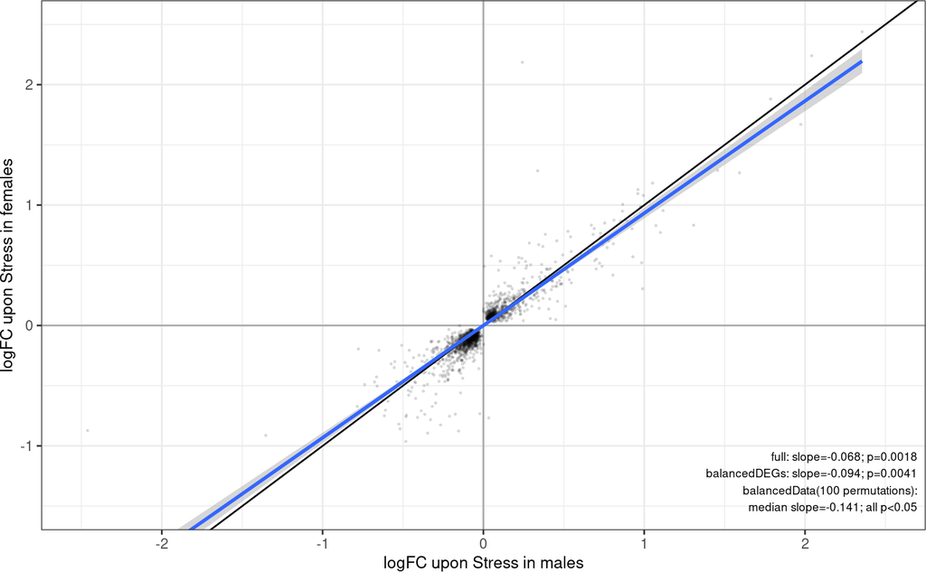

```r
# ======== Slope analysis across all three gene sets ========
# Model: (female logFC - male logFC) ~ male logFC
# If the slope is significantly non-zero, it means genes with a stronger male stress response also tend to show a bigger male vs. female difference
# i.e. the sex difference isn't random noise, it scales with the strength of the response itself.
# If the slope were ~0 and non-significant, it would suggest no such relationship
stats <- as.data.frame(t(sapply(list(full = m1, balancedDEGs = m2), \(x){
  coef(summary(lm(logFC.females - logFC.males ~ 0 + logFC.males, data = x)))[,-3]  # drop the t-statistic
  })))
anno_stat <- paste0(" ", row.names(stats), ": slope=", round(stats[,1], 3), "; p=", round(stats[,3], 4))
anno_stat <- c(
  anno_stat,
  paste0(" balancedData(", n_perm, " permutations):\nmedian slope=",
         sprintf("%.3f", median(as.numeric(slopes_balanced_data["Estimate",]))),
         "; all p<0.05")
)

fig6i <- ggplot(m1, aes(logFC.males, logFC.females)) +
  geom_vline(xintercept = 0, colour = "darkgray") +
  geom_hline(yintercept = 0, colour = "darkgray") +
  theme_bw() +
  coord_cartesian(xlim = c(-2.5, 2.5), ylim = c(-1.5, 2.5)) +
  geom_abline(slope = 1) + geom_point(alpha = 0.1, size = 0.3) +
  geom_smooth(formula = y ~ 0 + x, method = "lm") +
  labs(x = "logFC upon Stress in males", y = "logFC upon Stress in females") +
  theme(axis.title = element_text(size = 10)) +
  annotate("text", label = paste0("\n", paste(anno_stat, collapse = "\n")), x = 2.7, y = -Inf, hjust = 1, vjust = -0.25, size = 2.5)
fig6i
```

In the plot we see the slope is slighly negative (the regression slope falls below y=x curve), in all results from the three gene sets. This indicates that females show slightly weaker stress response in our experiments.

### 1.3.7 Fig 6J

This plot is to show the permutation results

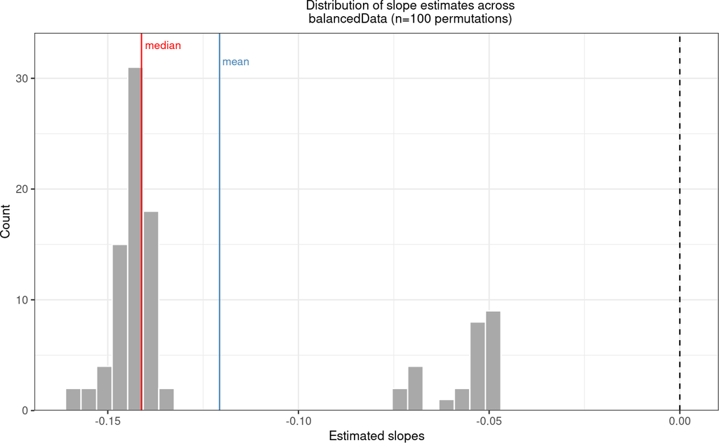

```r
fig6j <- ggplot(t(slopes_balanced_data), aes(x = Estimate)) +
  geom_histogram(bins = 40, fill = "darkgrey", color = "white") +
  theme_bw() +
  geom_vline(xintercept = 0, colour = "black", linetype = "dashed") +
  geom_vline(xintercept = median(as.numeric(slopes_balanced_data["Estimate",])), colour = "red") +
  geom_vline(xintercept = mean(as.numeric(slopes_balanced_data["Estimate",])), colour = "steelblue") +
  annotate("text", x = median(as.numeric(slopes_balanced_data["Estimate",])), y = Inf, label = "median",
           colour = "red", hjust = -0.1, vjust = 2, size = 3) +
  annotate("text", x = mean(as.numeric(slopes_balanced_data["Estimate",])), y = Inf, label = "mean",
           colour = "steelblue", hjust = -0.1, vjust = 4, size = 3) +
  scale_y_continuous(expand = expansion(mult = c(0, 0.1))) +
  theme(legend.key.size = unit(0.3, "cm"),
        legend.text = element_text(size = 6),
        legend.title = element_text(size = 6),
        plot.title.position = "plot",
        plot.title = element_text(size = 10, hjust = 0.6),
        axis.title = element_text(size = 10)) +
  labs(x = "Estimated slopes", y = "Count", title = "Distribution of slope estimates across\nbalancedData (n=100 permutations)")
fig6j
```

# 2 Save objects for later use

```r
stress_degs_MFunion <- union(M_signif, F_signif) # save this for later use
stressed_animals <- se[,se$Condition == "Stress"]$SampleName
mean_log2fc <- rowMeans(assay(se, "log2FC")[stress_degs_MFunion, stressed_animals])
filtered_stress_degs_MFunion <- mean_log2fc[abs(mean_log2fc) > 0.1]

DEGs <- list(
  MF_union_stress_degs = stress_degs_MFunion,
  MF_stress_degs_filtered = filtered_stress_degs_MFunion,
  Interaction_degs_stageR_by_allResults = intDEGs,
  Interaction_degs_stageR_by_subsetResults = intDEGs2)

reference_obj = list(se = se,
                   DEGs = DEGs,
                   edgeR = Results)
saveRDS(reference_obj, "./objects/reference_analysis_obj.rds")
```

# 3 Summary Fig 6

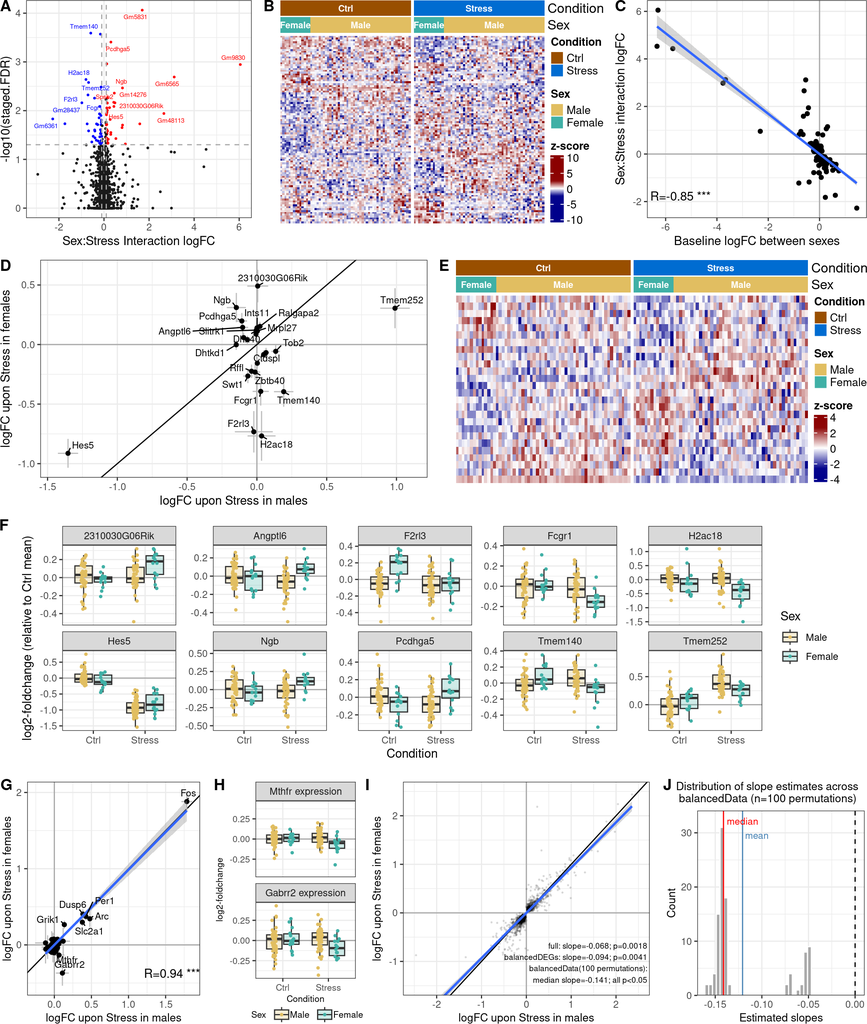

```r
fig6 <- plot_grid(
          plot_grid(fig6a + theme(legend.position = "none"),
                    as.ggplot(function() draw(fig6b, merge_legends = TRUE)) + theme(plot.margin = margin(0, 0, 22, 15)),
                    fig6c,
                    nrow = 1, labels = "AUTO", rel_widths = c(3,4,3)),
          plot_grid(fig6d,
                    as.ggplot(function() draw(fig6e, merge_legends = TRUE)) + theme(plot.margin = margin(0, 0, 22, 15)),
                    labels = LETTERS[4:5]),
          plot_grid(fig6f, scale = 0.95, labels = "F"),
          plot_grid(fig6g,
                    fig6h,
                    fig6i,
                    fig6j,
                    scale = 0.98, labels = LETTERS[7:10], nrow = 1, rel_widths = c(2.9,2.1,4,2.9)),
          nrow = 4)
fig6
```

```r
pdf("./figures/fig6_reference_analysis.pdf", width = 11, height = 13)
fig6
dev.off()
```

# 4 Supplement Figure 2: Check Overall Stress Response and Baseline Sex difference

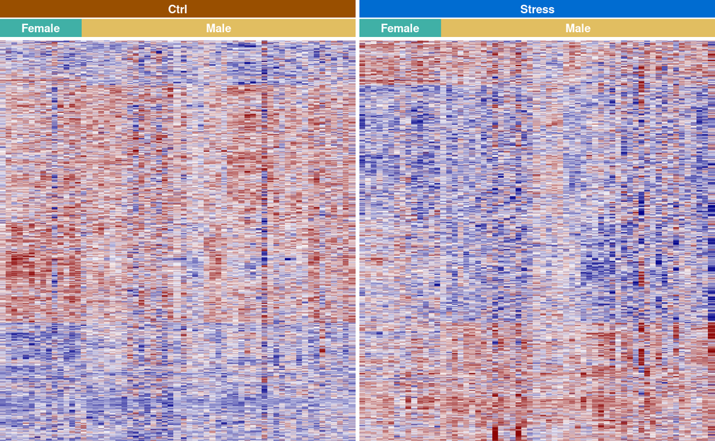

```r
Results_stress_simu_sex <- as.data.frame(topTags(glmQLFTest(fit, contrast = contrast[, c("F_Stress", "M_Stress")]),Inf))
# Simultaneously testing the StressMale-CtrlMale and StressF-CtrlF (not the average)
DEGs_stress_simu_sex <- rownames(Results_stress_simu_sex)[Results_stress_simu_sex$FDR < 0.05]

supp_fig2a_left <- sechm(
  se = se,
  feature = DEGs_stress_simu_sex,
  gaps_at = "Condition",
  assayName = "corrected",
  do.scale = TRUE,
  anno_labels = TRUE,
  anno_label_gp = list(col = "white", size = 9),
  name = "z-score",
  top_annotation = c("Condition", "Sex"),
  show_rownames = FALSE,
  show_heatmap_legend = FALSE,
  show_annotation_legend = FALSE,
  annocol_title_side = NA,
  breaks = 0.95,
  cluster_rows = TRUE,
  show_row_dend = FALSE,
  column_title = NULL,
  use_raster = TRUE
)

shared_legends <- get_ht_legend(supp_fig2a_left)

# calculate a common scale for later use
cs <- commonScale(supp_fig2a_left)

# change it to ggplot object
supp_fig2a_left<- as.ggplot(function(){draw(supp_fig2a_left, merge_legends=TRUE)})
supp_fig2a_left
```

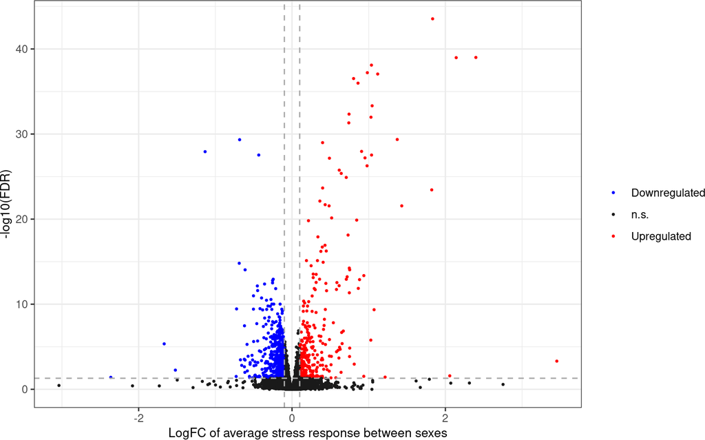

```r
supp_fig2a_right <- volcano(Results_stress, logFC = logFC, signif = FDR) +
  labs(x = "LogFC of average stress response between sexes") +
  theme(axis.title = element_text(size = 10))
supp_fig2a_right
```

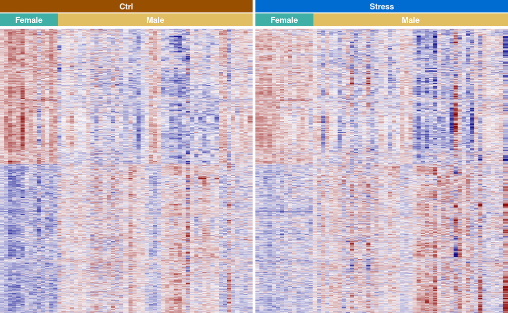

```r
DEGs_sex_baseline <- rownames(Results_sex)[Results_sex$FDR < 0.05]
supp_fig2b_left <- sechm(
  se = se,
  feature = DEGs_sex_baseline,
  gaps_at = "Condition",
  assayName = "corrected",
  do.scale = TRUE,
  name = "z-score",
  top_annotation = c("Condition", "Sex"),
  anno_labels = TRUE,
  anno_label_gp = list(col = "white", size = 9),
  show_heatmap_legend = FALSE,  # show it later using shared legend
  show_annotation_legend = FALSE,
  annocol_title_side = NA,
  show_rownames = FALSE,
  cluster_rows = TRUE,
  show_row_dend = FALSE,
  breaks = cs$breaks,
  hmcols = cs$hmcols,
  column_title = NULL,
  use_raster = TRUE
)

# change it to ggplot object
supp_fig2b_left <- as.ggplot(function(){draw(supp_fig2b_left, merge_legends=TRUE)})
supp_fig2b_left
```

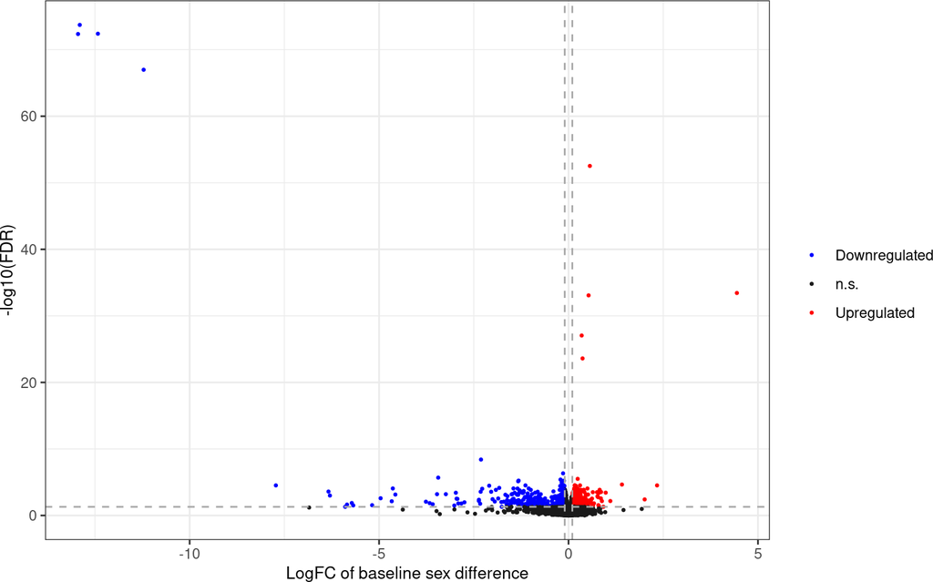

```r
supp_fig2b_right <- volcano(Results_sex, logFC = logFC, signif = FDR) +
  labs(x = "LogFC of baseline sex difference") +
  theme(axis.title = element_text(size = 10))
supp_fig2b_right
```

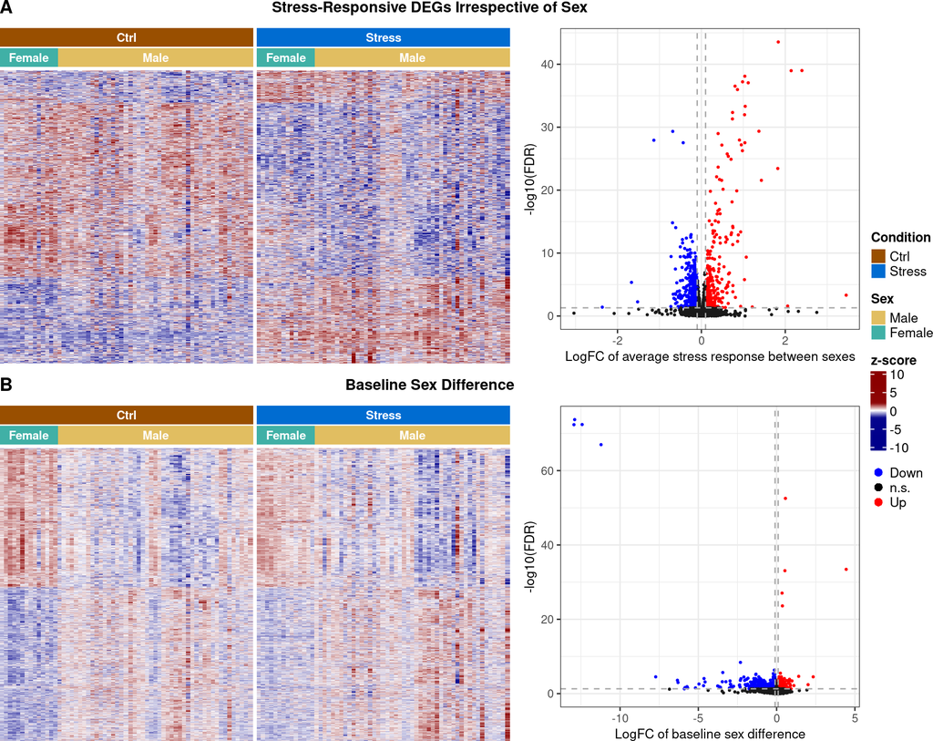

```r
title1 <- ggplot() +
  annotate("text", x = 0.5, y = 0.5, label = "Stress-Responsive DEGs Irrespective of Sex", size = 4, fontface = "bold") +
  theme_void()
title2 <- ggplot() +
  annotate("text", x = 0.5, y = 0.5, label = "Baseline Sex Difference", size = 4, fontface = "bold") +
  theme_void()

volc_legend <- Legend(
  labels = c("Down", "n.s.", "Up"),
  type = "points", pch = 16,
  legend_gp = gpar(col = c("blue", "black", "red")),
  background = "white",
  size = unit(3, "mm"),
  labels_gp = gpar(fontsize = 10)
)
all_legend <- do.call(packLegend, c(list(shared_legends, volc_legend),
                                    list(direction = "vertical", gap = unit(4, "mm"))))
legend_col <- as.ggplot(function() draw(all_legend))

supp_fig2b <- plot_grid(
                plot_grid(
                  plot_grid(title1, labels = c("A")),
                  plot_grid(supp_fig2a_left,
                            supp_fig2a_right + theme(legend.position = "none"),
                            nrow = 1, rel_widths = c(1.5, 1)),
                  plot_grid(title2, labels = c("B")),
                  plot_grid(supp_fig2b_left,
                            supp_fig2b_right + theme(legend.position = "none"),
                            nrow = 1, rel_widths = c(1.5, 1)),
                  nrow = 4, rel_heights = c(0.08, 1, 0.08, 1)),
                  legend_col, ncol = 2, rel_widths = c(1, 0.08)
              )
supp_fig2b
```

```r
pdf("./supplements/supp_stress_sex_general_effect.pdf", width = 10, height = 8)
supp_fig2b
dev.off()
```

# 5 Supplement Figure 3: Check Poorness-of-fit

To test whether our genes violated the assumption of the negative binomial model

```r
pval_poorlyfit <- edgeR::gof(fit)$gof.pvalues
names(pval_poorlyfit) <- rownames(fit$coefficients)
rowData(se)$poorlyfit.pvalue <- pval_poorlyfit[rownames(se)]

all_genes <- rownames(fit$coefficients)
stress_genes <- rownames(Results_stress[Results_stress$FDR < 0.05, ])

df_combined <- rbind(
  data.frame(neg_log10p = -log10(rowData(se)$poorlyfit.pvalue), group = "All genes", gene = gsub(".+\\.", "", names(rowData(se)$poorlyfit.pvalue))),
  data.frame(neg_log10p = -log10(rowData(se[stress_genes,])$poorlyfit.pvalue), group = "Stress DEGs", gene = gsub(".+\\.", "", names(rowData(se[stress_genes,])$poorlyfit.pvalue))),
  data.frame(neg_log10p = -log10(rowData(se[intDEGs2,])$poorlyfit.pvalue), group = "Interaction DEGs", gene = gsub(".+\\.", "", names(rowData(se[intDEGs2,])$poorlyfit.pvalue)))
)
df_combined$group <- factor(df_combined$group, levels = c("All genes", "Stress DEGs", "Interaction DEGs"))

# define outliers
outliers <- subset(
  df_combined,
  group == "Interaction DEGs" & neg_log10p > 50 & is.finite(neg_log10p)  # choose your threshold
)

# Wilcoxon test
w1 <- wilcox.test(rowData(se)$poorlyfit.pvalue[stress_genes], rowData(se)$poorlyfit.pvalue)  # Stress DEGs vs. All genes
w2 <- wilcox.test(rowData(se)$poorlyfit.pvalue[intDEGs2],    rowData(se)$poorlyfit.pvalue[stress_genes])  # Interaction DEGs vs. Stress DEGs
res_wilcox <- data.frame(
  comparison = c("Stress DEGs vs. All genes", "Interaction DEGs vs. Stress DEGs"),
  n1 = c(length(stress_genes), length(intDEGs2)),
  n2 = c(length(all_genes), length(stress_genes)),
  median_neglog10p_1 = c(median(-log10(rowData(se)$poorlyfit.pvalue[stress_genes])), median(-log10(rowData(se)$poorlyfit.pvalue[intDEGs2]))),
  median_neglog10p_2 = c(median(-log10(rowData(se)$poorlyfit.pvalue)), median(-log10(rowData(se)$poorlyfit.pvalue[stress_genes]))),
  p = c(w1$p.value, w2$p.value)
)
res_wilcox
```

```
##                         comparison   n1    n2 median_neglog10p_1
## 1        Stress DEGs vs. All genes 1637 15399           1.542511
## 2 Interaction DEGs vs. Stress DEGs   32  1637           2.268573
##   median_neglog10p_2         p
## 1           1.590416 0.7507171
## 2           1.542511 0.0776282
```

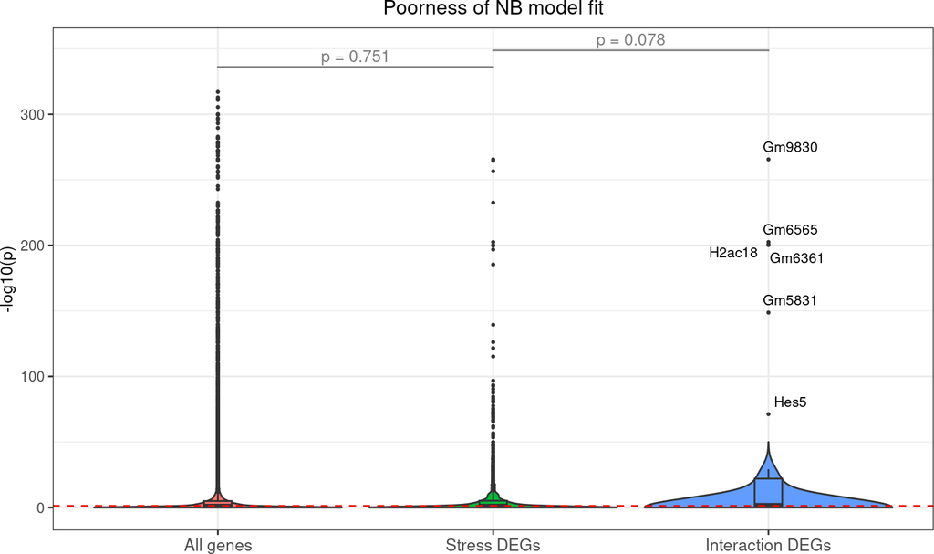

```r
# violin plot
y_top <- max(df_combined$neg_log10p[is.finite(df_combined$neg_log10p)])
fmt   <- function(p) paste0("p = ", format.pval(p, digits = 2))

pof <- ggplot(df_combined, aes(x = group, y = neg_log10p, fill = group)) +
  geom_violin(scale = "width", bounds = c(0, 50)) + # estimate the kernel density using data points with y<50
  geom_boxplot(width = 0.1, outlier.size = 0.5) +
  geom_hline(yintercept = -log10(0.05), color = "red", linetype = "dashed") +
  geom_text_repel(
    data = outliers,
    aes(label = gene),
    size = 3,
    max.overlaps = Inf
  ) +
  theme_bw() +
  theme(legend.position = "none",
        plot.title = element_text(size = 12, hjust = 0.5),
        axis.text.x = element_text(size = 10),
        axis.title.y = element_text(size = 10)) +
  labs(x = "", y = "-log10(p)",
       title = "Poorness of NB model fit") +
  ggsignif::geom_signif(
  comparisons = list(c("All genes", "Stress DEGs"),
                     c("Stress DEGs", "Interaction DEGs")),
  annotations = paste0("p = ", format.pval(res_wilcox$p, digits = 2)),
  y_position = y_top * c(1.01, 1.05),
  tip_length = 0, textsize = 3.5, color = "grey50"
)
pof
```

```r
ggsave("./supplements/supp_pof.pdf", plot = pof)
```

# Reference

Brivio, Elena, Juan Pablo Lopez, and Alon Chen. 2020. “Sex Differences: Transcriptional Signatures of Stress Exposure in Male and Female Brains.” *Genes, Brain, and Behavior* 19 (3): e12643. https://doi.org/10.1111/gbb.12643.